# R Notebook

Equipo 4

```r
library(dplyr)
library(tidyverse)
library(ggpubr)
library(ez)
library(latex2exp)
```

```r
datos = read.csv2("EP05 Datos.csv")

# Datos en formato largo
data <- datos %>% filter(tipo == "2x2x2" & (pais == "Colombia" | pais == "Argentina" | pais == "Ecuador"))
```

Formulación de Hipótesis

H0:El tiempo en promedio necesitado para resolver el cubo de 2x2x2 (u^(2x2x2)) es igual para Colombia, Ecuador y Argentina.

Ha: El tiempo en promedio necesitado para resolver el cubo de 2x2x2 es diferente para al menos un país.

Matemáticamente

H0: u_Colombia^(2x2x2}) = u_Ecuador^(2x2x2) = u_Argentina^(2x2x2)

Ha: ∃ i, j ∈ {Colombia, Ecuador, Argentina}, i != j or u_i^(2x2x2) != u_j^(2x2x2)

Prueba de condiciones

1. Al medir en base al tiempo, se determina que efectivamente es una escala con interrvalos iguales, ya que el tiempo es una magnitud física.
2. En base al enunciado se comprueba que las muestras fueron obtenidas de manera aleatoria e independiente.

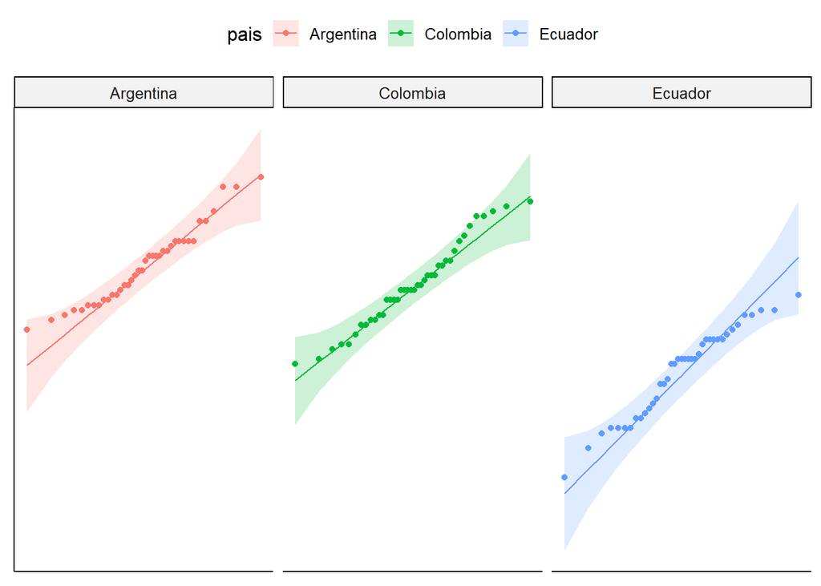

```r
# 3. Comprobación de normalidad
data[["pais"]] = factor(data[["pais"]])
data[["instancia"]] = factor(1:nrow(data))

# Crear gráfico Q-Q para la columna 'tiempo'
g = ggqqplot(data,
             x = "tiempo",
             y = "pais",
             color = "pais")
g = g + facet_wrap(~ pais)
g = g + rremove("x.ticks") + rremove("x.text")
g = g + rremove("y.ticks") + rremove("y.text")
g = g + rremove("axis.title")

# Imprimir el gráfico
print(g)
```

```r
test_normalidad = data %>% group_by(pais) %>% summarise(p = shapiro.test(tiempo)$p.value)
print(test_normalidad)
```

```
## # A tibble: 3 × 2
##   pais          p
##   <fct>     <dbl>
## 1 Argentina 0.145
## 2 Colombia  0.374
## 3 Ecuador   0.129
```

Gracias al gráfico y el test de Shapiro Wilk, se determina que la muestra efectivamente sigue una distribución normal.

```r
# 4. Verificar condición de homocedasticidad y prueba ezANOVA
prueba = ezANOVA(data = data, dv = tiempo, between = pais, wid = instancia, type = 2, return_aov = TRUE)
```

```
## Coefficient covariances computed by hccm()
```

```r
print(prueba)
```

```
## $ANOVA
##   Effect DFn DFd        F            p p<.05       ges
## 1   pais   2 114 69.13973 2.169245e-20     * 0.5481202
##
## $`Levene's Test for Homogeneity of Variance`
##   DFn DFd         SSn       SSd         F         p p<.05
## 1   2 114 0.001341979 0.3170392 0.2412724 0.7860277
##
## $aov
## Call:
##    aov(formula = formula(aov_formula), data = data)
##
## Terms:
##                      pais Residuals
## Sum of Squares  1.0194613 0.8404617
## Deg. of Freedom         2       114
##
## Residual standard error: 0.0858631
## Estimated effects may be unbalanced
```

Según el resultado de la prueba de homocedasticidad de varianza con un p-value: 0.7860277 se puede determinar que efectivamente las varianzas cumplen la condición de homogeneidad.

Interpretación prueba omnibus

Según el p-value de la prueba ANOVA, el cual es prácticamente cero, se puede determinar que existe una diferencia significativa entre, por lo menos, dos países. Esto permite que se rechace la hipótesis nula en favor de la alternativa.

Interpretación de la prueba ommnibus

```r
#Gráfico tamaño del efecto

g2 <-ezPlot(
  data = data,
  dv = tiempo,
  wid = instancia,
  between = pais,
  y_lab = "Tiempo promedio para resolver un cubo 2X2X2 [S]",
  x = pais
)
```

```
## Coefficient covariances computed by hccm()
```

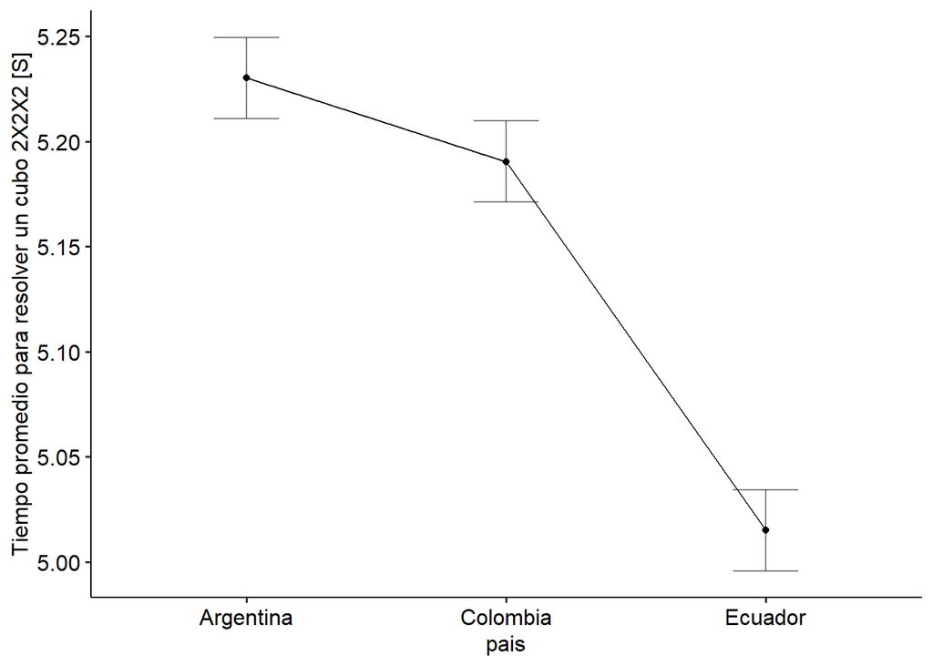

```r
g2 <- g2 + theme_pubr()

print(g2)
```

Prueba post hoc

Dado que el ANOVA indica diferencias entre diferencias estadísticas significativas entre al menos dos países, es necesario realizar un análisis extra para saber entre cuáles países existe dicha diferencia.

Para esto haremos uso de la prueba Post-hoc

```r
#Procedimiento TukeyHSD

anova <- aov(tiempo ~ pais, data = data)

post_hoc <- TukeyHSD(anova,
                     "pais",
                     ordered =TRUE,
                     conf.level = 1- 0.05)

print(post_hoc)
```

```
##   Tukey multiple comparisons of means
##     95% family-wise confidence level
##     factor levels have been ordered
##
## Fit: aov(formula = tiempo ~ pais, data = data)
##
## $pais
##                          diff          lwr        upr     p adj
## Colombia-Ecuador   0.17562821  0.129743355 0.22151306 0.0000000
## Argentina-Ecuador  0.21539136  0.168914230 0.26186850 0.0000000
## Argentina-Colombia 0.03976316 -0.006426376 0.08595269 0.1063885
```

En conclusión, con un nivel de significacia de (a = 0.05). Si miramos el gráfico del efecto obtenido para el procedimiento ANOVA, podemos concluir con un 95% de confianza que en Ecuador tienen un tiempo de resolución promedio menor al de Colombia o Argentina. Respecto a Argentina y Colombia, no hay diferencias significativas entre sus medias.